# Statistica Medica — Corrado Lanera – Statistica Medica

[figure not shown]

[figure not shown]

[figure not shown]


# Statistica Medica

Basi di probabilità

Corrado Lanera

[Unità di Biostatistica, Epidemiologia e Salute Pubblica](https://www.unipd-ubep.it/), Università di Padova

18 novembre 2026

## Cosa faremo

Inizieremo richiamando alcune definizioni e proprietà base della probabilità come il concetto di **evento** e **probabilità** stessa.

Vedremo come questi elementi si combinano tra loro con le operazioni di base quali **somma**, **prodotto**, e **complemento** (corrispondenti agli analoghi insiemistici di *unione*, *intersezione*, e *complementare*). In particolare introdurremo il concetto di **indipendenza** e vedremo come questo interagisce con le operazioni base.

A questo punto saremo pronti per introdurre la parte interessante della probabilità, ovvero come la conoscenza del verificarsi di un dato evento **condizioni** la nostra conoscenza sulla probabilità del verificarsi di un altro. Ne vedremo una prima applicazione al caso dei **rischi relativi** e alle misure di valutazione per i **test di screening**.

Quest’ultime ci daranno il pretesto per apprezzare la differenza fondamentale, quando siamo di fronte a due eventi, tra quello eventualmente noto e quello ignoto, e come poter *girare* i condizionamenti tramite il **teorema di Bayes** in modo da poter calcolare le misure che ci interessano (e non possiamo conoscere a priori) a partire da quelle che conosciamo (o possiamo conoscere a priori), anche quando i test sono due, fatti uno dopo l’altro.

## Riconoscimenti

- Le diapositive proposte sono state prodotte a partire anche da materiale generato da/con le seguenti persone gravitanti attorno all’UBEP*:
  - Danila Azzolina
  - Dario Gregori
  - Giulia Lorenzoni
  - Honoria Ocagli
  - Ileana Baldi
  - Luca Vedovelli
  - Matteo Martinato
  - Paola Berchialla

* In ordine alfabetico.

> Un ringraziamento speciale a Cristiana Vettori per l’aiuto e il supporto logistico e amministrativo che mi è stato offerto.

## **Panoramica**

**Definizioni**, **proprietà** e **notazioni** fondamentali

**Operazioni** base tra eventi

**Condizionamento**, **rischio relativo**, e misure per **test di screening**

**Teorema di Bayes**

## **Definizioni, proprietà e notazioni fondamentali**

- **Eventi** e **probabilità**
- Eventi **mutuamente esclusivi**
- **Intersezione**, **unione**, e **complemento**

## Definizione: evento e probabilità

Lo **spazio degli eventi** $\Omega$ è l’insieme di tutti i possibili risultati di un esperimento probabilistico.

Un **evento** è un qualsiasi insieme di risultati di un esperimento probabilistico (ovvero, un sottoinsieme di $\Omega$).

Un **risultato** di un esperimento probabilistico *verifica* un evento se ne fa parte.

La **probabilità** di un evento è la frequenza relativa dei risultati che lo definiscono, valutata su **infinite ripetizioni** dell’esperimento probabilistico.

##### Esempio

- Esperimento: misura della pressione diastolica (DBP) di una persona presa a caso, in un determinato momento, nella popolazione.
- Spazio degli eventi $\Omega$: ogni possibile misura di DBP.
- Evento $A$ : DBP $\geq 95$ mmHg.
- Risultato (mio, ora): DBP $= 70$ mmHg. (Non fa parte dell’evento, quindi non lo verifica)
- Probabilità di $A$ : misurando la DBP, ora, a tutta la popolazione, la porzione di persone con DBP $\geq 95$ mmHg.

## Notazione: unione

- il simbolo $\{ \}$ si usa per indicare un evento
- il simbolo $\cup$ si usa come operatore per indicare l’evento unione $A \cup B$, ovvero tale per cui si verifichi $A$ o $B$ (o entrambi).

##### Esempio

**Sia** ($x$ la DBP):

- $A = \{x < 90 \}$
- $B = \{90 \leq x < 95 \}$
- $C = \{ x \geq 90 \}$
- $D = \{75 \leq x \leq 100 \}$

**Allora**:

$$A \cup B = \{ x < 95 \}$$

$$C \cup D = \{ x \geq 75 \}$$

## Eventi e spazio $\Omega$

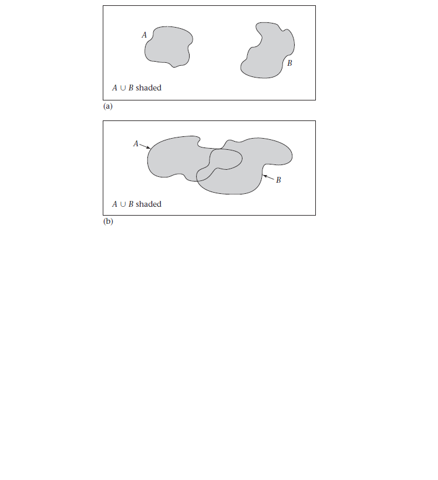

## Proprietà della probabilità

La probabilità di un evento $E$, indicata come $P(E)$, soddisfa sempre la condizione

$$0 \leq P(E) \leq 1$$

Se $A$ e $B$ sono due eventi che non possono verificarsi contemporaneamente, la probabilità che si verifichi $A$ o $B$ è la somma delle loro probabilità:

$$P(A \cup B) = P(A) + P(B)$$

##### Esempio

**Siano** ($x$ la DBP):

- $A = \{x < 90 \}$, DBP normale
- $B = \{90 \leq x < 95 \}$, DBP borderline
- $C = A \cup B = \{x < 95 \}$

**Se**:

- $P(A)=0.7$
- $P(B)=0.1$

**Allora**: $P(C) = P(A \cup B) = P(A) + P(B) = 0.7 + 0.1 = 0.8$.

## Proprietà: eventi mutuamente esclusivi

Due eventi $A$ e $B$ si dicono **mutuamente esclusivi** se non possono verificarsi contemporaneamente.

##### Esempio

**Siano** ($x$ la DBP):

- $C = \{x \geq 90 \}$
- $D = \{75 \leq x \leq 100 \}$

**Allora** in questo caso:

$C$ e $D$ **non** sono mutuamente esclusivi, in quanto entrambi si verificano quando $90 \leq x \leq 100$.

## Notazione: intersezione

Il simbolo $\cap$ indica l’evento $A \cap B$, per cui sia $A$ che $B$ si verificano contemporaneamente.

##### Esempio

**Dati** ($x$ la DBP):

- $C = \{x\geq 90\}$
- $D = \{75 \leq x \leq 100 \}$

**Allora**:

$$C \cap D = \{90 \leq x \leq 100 \}$$

## Intersezione di eventi

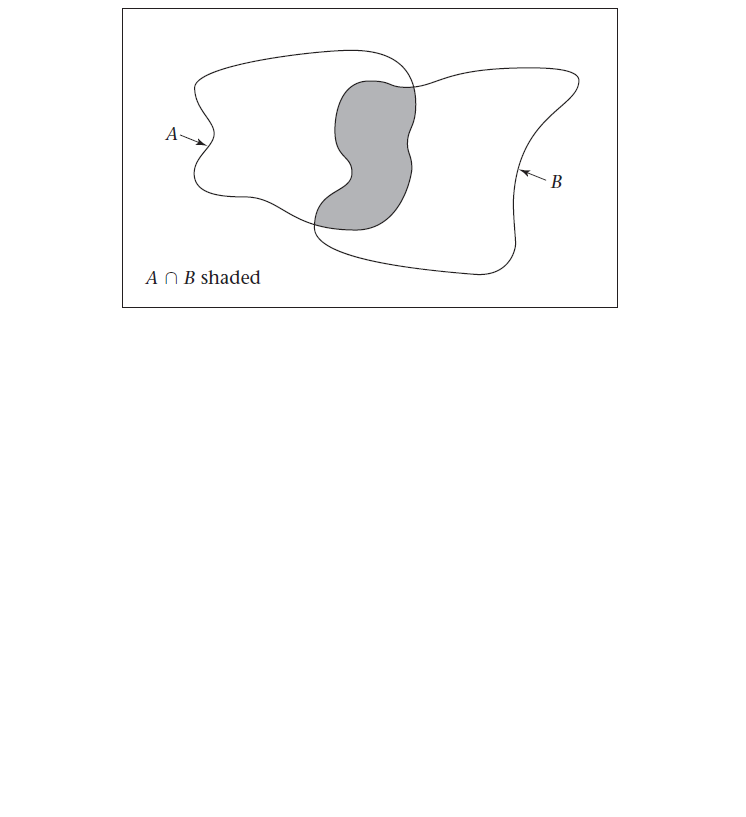

## Notazione: complemento

Con $\bar{A}$ si indica l’evento per cui $A$ non si verifica e si chiama complemento di $A$.

Vale **sempre**:

$$P(\bar{A}) = 1-P(A)$$

##### Esempio

**Dati** ($x$ la DBP):

- $A = \{x < 90 \}$, con $P(A) = 0.7$
- $C =\{x \geq 90 \}$

**Allora**:

$$\bar{A}=C$$

**Da cui**:

$$P(C) = P(\bar{A}) = 1-0.7 = 0.3$$

## Evento complementare

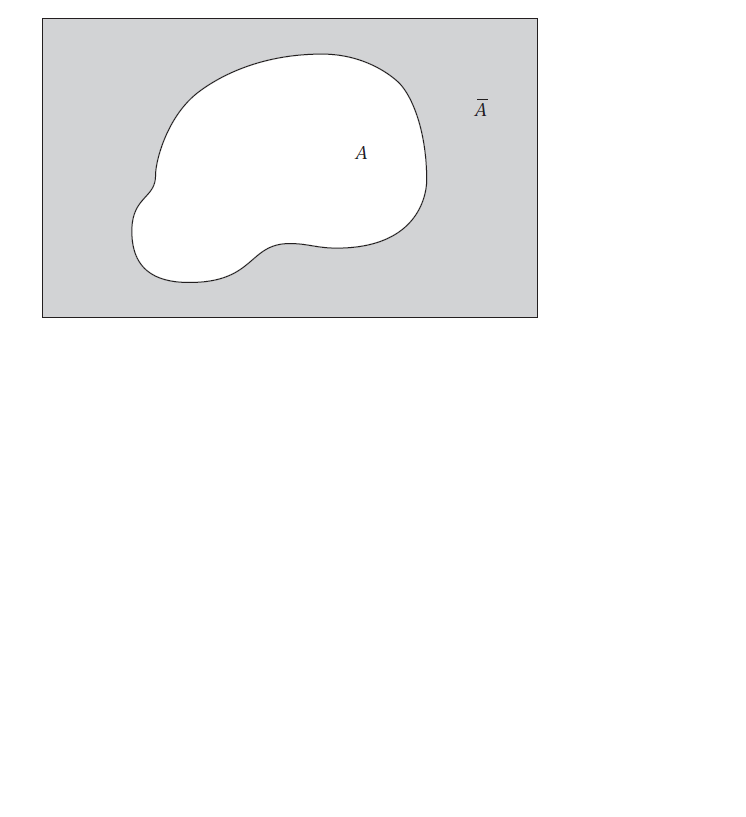

## Mappa: Definizioni e notazioni

- Mappa
- Indice

```
%%{init: {"htmlLabels": false, "flowchart": {"padding": 12, "wrappingWidth": 320}, "themeVariables": {"fontFamily": "Arial, Helvetica, sans-serif"}}}%%
flowchart LR
  k_n_02_classi["Classi e medie ponderate · 02"]:::prev
  n_esperimento_casuale["Esperimento casuale"]:::cur
  n_spazio_campionario["Spazio degli eventi Ω"]:::cur
  n_evento["Evento"]:::cur
  n_probabilita["Probabilità"]:::cur
  n_limiti_della_probabilita["0 ≤ P(E) ≤ 1"]:::cur
  n_additivita_eventi_incompatibili["Somma per incompatibili"]:::cur
  n_eventi_incompatibili["Eventi incompatibili"]:::cur
  n_notazione_evento_graffe["Notazione {…}"]:::cur
  n_unione_di_eventi["Unione (∪)"]:::cur
  n_diagramma_di_venn["Diagramma di Venn"]:::cur
  n_intersezione_di_eventi["Intersezione (∩)"]:::cur
  n_evento_complementare["Complementare"]:::cur
  k_n_02_classi --> n_probabilita
  n_esperimento_casuale --> n_spazio_campionario
  n_eventi_incompatibili --> n_additivita_eventi_incompatibili
  n_evento --> n_diagramma_di_venn
  n_evento --> n_eventi_incompatibili
  n_evento --> n_notazione_evento_graffe
  n_evento --> n_probabilita
  n_notazione_evento_graffe --> n_intersezione_di_eventi
  n_notazione_evento_graffe --> n_unione_di_eventi
  n_probabilita --> n_additivita_eventi_incompatibili
  n_probabilita --> n_evento_complementare
  n_probabilita --> n_limiti_della_probabilita
  n_spazio_campionario --> n_evento
  classDef cur fill:#e6f0fa,stroke:#035AA6,color:#000000
  classDef prev fill:#f4f4f4,stroke:#9a9a9a,color:#555555,stroke-dasharray:4 3
  classDef opt fill:#ffffff,stroke:#035AA6,color:#555555,stroke-dasharray:2 2
```

Ogni freccia va da un concetto a quelli che lo usano. In grigio i concetti delle sezioni o dei deck precedenti (con il numero del deck).

- Esperimento casuale
- Spazio degli eventi Ω
- Evento
- Probabilità
- 0 ≤ P(E) ≤ 1
- Somma per incompatibili
- Eventi incompatibili
- Notazione {…}
- Unione (∪)
- Diagramma di Venn
- Intersezione (∩)
- Complementare

## **Operazioni di base**

- **Prodotto** (e **indipendenza**)
- **Somma** (e **indipendenza**)

## Prodotto: indipendenza

Due eventi sono indipendenti se

$$P(A \cap B) = P(A)P(B)$$

### Teorema del prodotto

**Se**: $A_1, \ldots, A_k$ sono mutuamente indipendenti

**Allora**: $P(A_1 \cap A_2 \cap \ldots \cap A_k) = P(A_1)P(A_2)\ldots P(A_k)$

## Prodotto: esempio

Uno screening dell’ipertensione a domicilio misura la pressione diastolica (DBP) di madre, padre e primo figlio, per capire se l’ipertensione si concentra nelle famiglie.

##### Madre e padre

- $A=\{\mbox{DBP madre}\geq 95\}$, $P(A) = 0.1$
- $B=\{\mbox{DBP padre}\geq 95\}$, $P(B) = 0.2$
- $P(A \cap B) = 0.02$

**Allora**:

$$P(A \cap B) = 0.02 = P(A)P(B)$$

Gli eventi sono indipendenti: madre e padre non sono parenti di sangue.

##### Madre e primo figlio

- $A=\{\mbox{DBP madre}\geq 95\}$, $P(A) = 0.1$
- $C=\{\mbox{DBP figlio}\geq 80\}$, $P(C) = 0.2$
- $P(A \cap C) = 0.05$

**Allora**:

$$P(A \cap C) = 0.05 > 0.02 = P(A)P(C)$$

Gli eventi sono dipendenti: madre e figlio condividono geni e ambiente.

## indipendenza

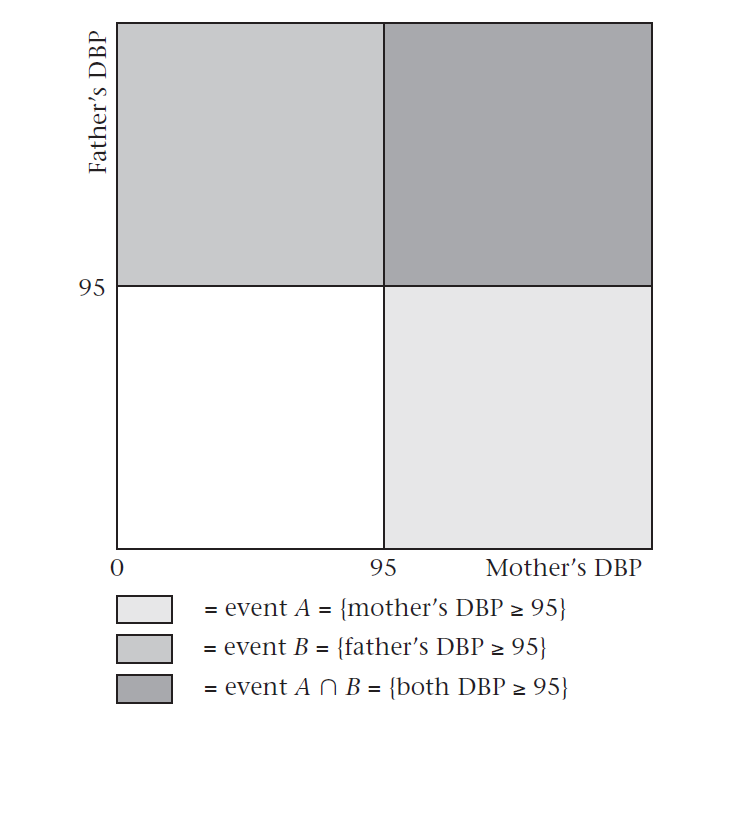

## Teorema della somma

**Siano**:

- $A$ e $B$ due eventi qualsiasi

**Allora**:

$$P(A \cup B) = P(A)+P(B)-P(A\cap B)$$

## Teorema della somma: es.

Due medici, $A$ e $B$, diagnosticano tutti i pazienti afferenti a un centro per le malattie a trasmissione sessuale.

**Siano**:

- $A^+$ l’evento per cui il medico $A$ fa diagnosi positiva
- $B^+$ l’evento per cui il medico $B$ fa diagnosi positiva

con:

- $P(A^+)=0.1$
- $P(B^+)=0.17$
- $P(A^+ \cap B^+)=0.08$.

Si supponga che un paziente sia riferito per test laboratoristici supplementari se in presenza di **almeno una** diagnosi positiva.

La probabilità che un paziente venga riferito ai laboratori è

$$P(A^+ \cup B^+) = P(A^+) + P(B^+) - P(A^+ \cap B^+) = 0.1+0.17-0.08=0.19$$

## Somma

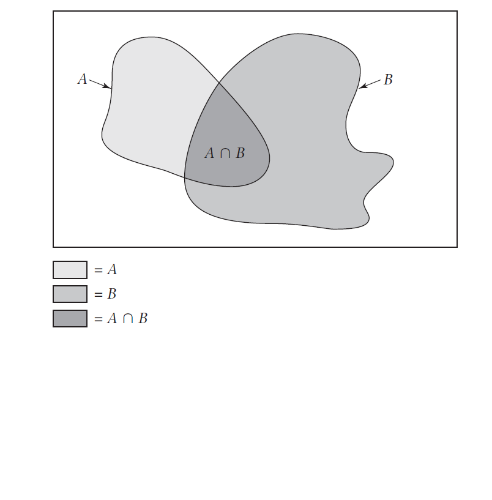

## Somma: indipendenza

**Sempre** (indipendenti o no):

$$P(A \cup B) = P(A) + P(B \cap \bar{A})$$

perché $A$ e $B \cap \bar{A}$ sono incompatibili (figura nella slide seguente).

**Se** $A$ e $B$ sono **indipendenti** (allora lo sono anche $\bar{A}$ e $B$):

$$P(B \cap \bar{A}) = P(B)P(\bar{A})$$

**quindi**:

$$P(A \cup B) = P(A) + P(B)[1 - P(A)]$$

## Somma: $A$ e $B \cap \bar{A}$

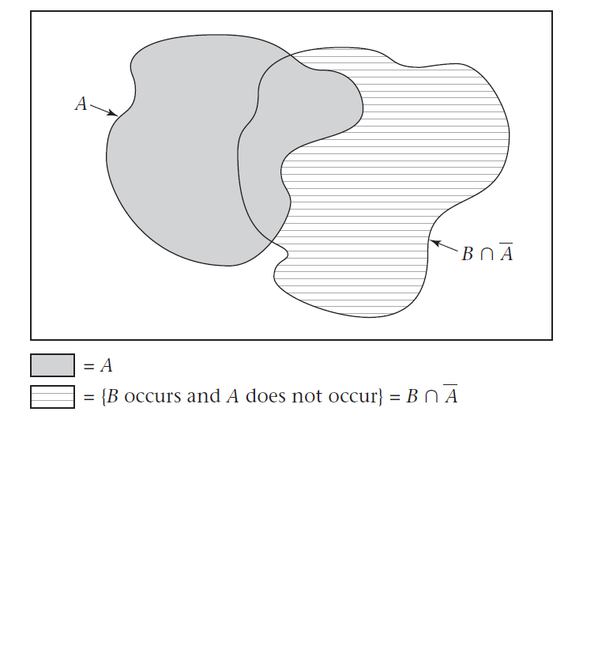

## Somma eventi indipendenti: esempio

Si considerino gli eventi

- $P(A)=P(\{\mbox{DBP madre}\geq 95 \})=0.1$
- $P(B)=P(\{\mbox{DBP padre}\geq 95 \})=0.2$

Si definisca come **famiglia ipertesa** quella in cui almeno uno dei genitori è iperteso.

**Allora** (essendo $A$ e $B$ indipendenti):

$$\begin{split} P(\{\mbox{famiglia ipertesa}\})& = P(A \cup B)\\&= P(A) + P(B\cap\bar{A}) \quad \mbox{(sempre)}\\&= P(A) + P(B)P(\bar{A}) \quad \mbox{(indipendenza)}\\& = P(A) + P(B)[1-P(A)]\\& = 0.1 + (0.2)[1-0.1]\\& = 0.28\end{split}$$

## Sondaggio

Per me: [Probabilità](https://app.wooclap.com/events/STATMEDPROB/0)

Per voi:

[figure not shown]

bit.ly/statmed-sondaggio-prob

## Mappa: Operazioni di base

- Mappa
- Indice

```
%%{init: {"htmlLabels": false, "flowchart": {"padding": 12, "wrappingWidth": 320}, "themeVariables": {"fontFamily": "Arial, Helvetica, sans-serif"}}}%%
flowchart LR
  n_additivita_eventi_incompatibili["Somma per incompatibili"]:::prev
  n_evento["Evento"]:::prev
  n_evento_complementare["Complementare"]:::prev
  n_intersezione_di_eventi["Intersezione (∩)"]:::prev
  n_probabilita["Probabilità"]:::prev
  n_unione_di_eventi["Unione (∪)"]:::prev
  n_eventi_indipendenti["Eventi indipendenti"]:::cur
  n_regola_del_prodotto["Prodotto (indipendenti)"]:::cur
  n_notazione_esito_positivo_negativo["Notazione + e −"]:::cur
  n_regola_della_somma["Regola della somma"]:::cur
  n_indipendenza_del_complementare["Indipendenza e complementare"]:::cur
  n_unione_come_somma_disgiunta["Unione come somma disgiunta"]:::cur
  n_somma_di_eventi_indipendenti["Somma per indipendenti"]:::cur
  n_additivita_eventi_incompatibili --> n_unione_come_somma_disgiunta
  n_eventi_indipendenti --> n_indipendenza_del_complementare
  n_eventi_indipendenti --> n_regola_del_prodotto
  n_evento --> n_notazione_esito_positivo_negativo
  n_evento_complementare --> n_indipendenza_del_complementare
  n_evento_complementare --> n_unione_come_somma_disgiunta
  n_indipendenza_del_complementare --> n_somma_di_eventi_indipendenti
  n_intersezione_di_eventi --> n_eventi_indipendenti
  n_intersezione_di_eventi --> n_regola_della_somma
  n_intersezione_di_eventi --> n_unione_come_somma_disgiunta
  n_probabilita --> n_eventi_indipendenti
  n_probabilita --> n_regola_della_somma
  n_regola_del_prodotto --> n_somma_di_eventi_indipendenti
  n_regola_della_somma --> n_somma_di_eventi_indipendenti
  n_unione_come_somma_disgiunta --> n_somma_di_eventi_indipendenti
  n_unione_di_eventi --> n_regola_della_somma
  n_unione_di_eventi --> n_unione_come_somma_disgiunta
  classDef cur fill:#e6f0fa,stroke:#035AA6,color:#000000
  classDef prev fill:#f4f4f4,stroke:#9a9a9a,color:#555555,stroke-dasharray:4 3
  classDef opt fill:#ffffff,stroke:#035AA6,color:#555555,stroke-dasharray:2 2
```

Ogni freccia va da un concetto a quelli che lo usano. In grigio i concetti delle sezioni o dei deck precedenti (con il numero del deck).

- Eventi indipendenti
- Prodotto (indipendenti)
- Notazione + e −
- Regola della somma
- Indipendenza e complementare
- Unione come somma disgiunta
- Somma per indipendenti

## Break

- sgranchirsi
- guardare *lontano* (rilassare gli occhi)
- bere
- andare in bagno

## Condizionamento, rischio relativo, misure per test di screening

- **Condizionamento**
- **Rischio relativo**
- **Sensibilità**, **specificità** e **valori predittivi**

## Condizionamento: definizione

La **probabilità condizionata** $P(B|A)$ (con $P(A) > 0$) è definita come

$$P(B|A)=\frac{P(A \cap B)}{P(A)}$$

**Se** due eventi sono indipendenti, **allora**

$$P(B|A)=P(B|\bar{A})=P(B)$$

Al contrario, **se** due eventi sono dipendenti, **allora**

$$P(B) \neq P(B|A) \neq P(B|\bar{A}) \neq P(B)$$
$$P(A \cap B) \neq P(A)P(B)$$

## Condizionamento: proprietà

Per qualsiasi evento $A$ e $B$ (con $0 < P(A) < 1$), si ha che

$$P(B) = P(B|A)P(A)+P(B|\bar{A})P(\bar{A})$$

che si deriva considerando che

$$P(B) = P(B\cap A)+P(B \cap \bar{A})$$
e ricordando la definizione
$$P(B|A)=\frac{P(A \cap B)}{P(A)}$$

da cui

$$P(A \cap B) = P(B|A)P(A)$$

## Condizionamento: esempio

Si ipotizzi che:

- **1 persona su 100** con skin test (SKT) positivo abbia la tubercolosi (TB)
- **1 persona ogni 10000** con SKT negativo abbia la TB
- l’1% della popolazione abbia SKT positivo

**Si calcoli** la probabilità di tubercolosi (TB) nella popolazione $P(TB)$, ovvero, si stimi la porzione di malati di tubercolosi nella popolazione (chiamata: la **prevalenza** della malattia)

**Soluzione**
$$\begin{split}P(TB)& =P(TB|SKT^+)P(SKT^+) + P(TB|SKT^-)P(SKT^-)\\& = (0.01)(0.01) + (0.0001)(1-0.01)\\& = 0.000199\end{split}$$

## Teorema delle probabilità totali

Un insieme di eventi $\mathscr{A} = \{A_1, \ldots, A_k\}$ è detto **esaustivo** se almeno uno di tali eventi **deve** verificarsi.

**Sia** $\mathscr{A} = \{A_1, \ldots, A_k\}$ un insieme esaustivo di eventi mutuamente esclusivi.

**Allora**, per qualunque evento $B$, la probabilità di $B$, $P(B)$, può essere scritta come:

$$\begin{split}P(B)& =\sum_{i=1}^k P(B|A_i)P(A_i)\\&\\&=\sum_{A\in \mathscr{A}} P(B|A)P(A)\end{split}$$
Ovvero, la **somma pesata** delle probabilità condizionali di $B$ dato $A_i$, $P(B|A_i)$ per le corrispondenti probabilità degli $A_i$ al variare di $i$ tra $1$ e $k$.

## Probabilità totali: esempio problema

- Problema
- Soluzione
- Conti

Si vuole pianificare uno studio sulla cataratta in una popolazione di **5000 persone** di età superiore a 60 anni.

Dal censimento è noto che la probabilità di appartenere a una delle seguenti classi di età 60-64, 65-69, 70-74, $\geq 75$ è pari rispettivamente a 0.45, 0.28, 0.20, 0.07.

Dal Framingham Eye Study è noto che la probabilità di sviluppare una cataratta a 5 anni di distanza è pari, rispettivamente per le classi di età indicate, a 0.024, 0.046, 0.088, 0.153.

Si vuole conoscere **la percentuale di persone che potrebbe sviluppare una cataratta nei prossimi 5 anni**, e una stima del loro numero.

| classe | p_classe | p_cataratta5y_classe |
| --- | --- | --- |
| 60-64 | 0.45 | 0.024 |
| 65-69 | 0.28 | 0.046 |
| 70-74 | 0.20 | 0.088 |
| 75+ | 0.07 | 0.153 |

La percentuale di popolazione (o probabilità, su tale popolazione) $P(B)$ per l’evento $B$ di sviluppare cataratta a 5 anni equivale, per il teorema delle probabilità totali, alla somma delle probabilità di svilupparla per ciascuna classe di età (che rappresentano un insieme **esaustivo** a elementi **mutuamente disgiunti**) pesate per la probabilità di appartenere a tali classi.

| insieme | classe | p_classe | p_cataratta5y_classe |
| --- | --- | --- | --- |
| A_1 | 60-64 | 0.45 | 0.024 |
| A_2 | 65-69 | 0.28 | 0.046 |
| A_3 | 70-74 | 0.20 | 0.088 |
| A_4 | 75+ | 0.07 | 0.153 |

Per esempio:

- Probabilità di sviluppo cataratta a 5 anni **se** nella classe “60-64”: $P(B|A_1) = 0.024$
- Probabilità di appartenere alla classe “60-64”: $P(A_1) = 0.45$

$$\begin{split}P(B)& = \sum_{i=1}^4 P(B|A_i)P(A_i)\\& =
(0.024)(0.45)+\ldots+(0.153)(0.07)\\& \simeq 0.052\end{split}$$

e il numero stimato di persone con cataratta sarà: $5000 \times 0.052 \simeq 260$ persone.

## Rischio relativo

Il rischio relativo (**RR**) di osservare, in una data popolazione, un evento $B$ su chi è esposto a un fattore $A$ rispetto a chi non ne è esposto ($\bar{A}$) è definito, tramite probabilità condizionate, come

$$\frac{P(B|A)}{P(B|\bar{A})}$$
> NOTA: > > **Se**: $A$ e $B$ sono indipendenti > > **Allora**: $RR = 1$ (infatti $P(B|A) = P(B|\bar{A}) = P(B)$)

## Rischio relativo: esempio

Si ipotizzi che:

- **1 persona su 100** con skin test (SKT) positivo abbia la tubercolosi (TB)
- **1 persona ogni 10000** con SKT negativo abbia la TB

Il rischio relativo di avere la TB nel caso di un test positivo rispetto a un test negativo è

$$RR=\frac{P(B|A)}{P(B|\bar{A})}=\frac{1/100}{1/10000}=\frac{0.01}{0.0001}=100$$

dove abbiamo indicato con $B$ l’evento di avere la TB, e con $A$ quello di avere un test positivo (ovvero con $\bar{A}$ di averlo negativo).

## Rischio relativo: attenzione al gonfiaggio

Il RR dice **quante volte** è più probabile l’evento, non **quanti** casi in più ci sono. Va letto insieme ai due rischi, $P(B \mid A)$ e $P(B \mid \bar{A})$.

- **Esempio della TB**: $RR = 100$, eppure fra i positivi allo skin test solo **1 su 100** ha la TB ($P(TB \mid SKT^+) = 0.01$); gli altri 99 no.
- **Il caso tipico degli articoli**: il rischio passa da 1 su 10000 a 2 su 10000.

  $$RR = \frac{2/10000}{1/10000} = 2$$

  «Il rischio raddoppia!», ma è **1 caso in più ogni 10000** persone.

## Rischio relativo: esempio problema

- Problema
- Soluzione $P(B^+|A^+)$
- Soluzione RR

Per i dati sul centro delle malattie a trasmissione sessuale, si è interessati a calcolare:

- la probabilità che il medico $B$ faccia diagnosi positiva data la diagnosi positiva del medico $A$
- il corrispondente rischio relativo.

Ricordando che

- $P(A^+) = 0.1$
- $P(B^+) = 0.17$
- $P(A^+ \cap B^+) = 0.08$

Partendo da $P(A \cap B) = P(B|A)P(A)$ otteniamo:

- $P(A^+)=0.1$
- $P(B^+)=0.17$
- $P(A^+ \cap B^+)=0.08$

$$\begin{split}P(B^+|A^+)& = \frac{P(B^+\cap A^+)}{P(A^+)}\\& = 0.08/0.1\\& = 0.8\end{split}$$

- $P(A^+)=0.1$
- $P(B^+)=0.17$
- $P(A^+ \cap B^+)=0.08$
- $P(B^+|A^+) = 0.8$

> Ricordiamo: $P(B^+)=P(B^+ \cap A^+)+P(B^+ \cap A^-)$

$$\begin{split}P(B^+|A^-)& = \frac{P(B^+\cap A^-)}{P(A^-)}\\& = \frac{P(B^+)-P(B^+\cap A^+)}
{P(A^-)}\\& =\frac{0.17-0.08}{0.9}\\& = 0.1\end{split}$$

$$RR=\frac{P(B^+|A^+)}{P(B^+|A^-)}=\frac{0.8}{0.1}=8$$

## Test di screening: valori predittivi

Il **valore predittivo positivo** (o anche **precisione**) $PV^+$ di un test di screening è la probabilità che la persona abbia la malattia dato un test positivo

$$PV^+ = P(\mbox{malattia}|\mbox{test}^+)$$

Il **valore predittivo negativo** $PV^-$ di un test di screening è la probabilità che la persona **non** abbia la malattia dato un test negativo

$$PV^- = P(\mbox{no malattia}|\mbox{test}^-)$$

Per esempio, nel caso della tubercolina si ha che

$$P(TB|SKT^+) = 0.01 = PV^+$$

$$P(\bar{TB}|SKT^-) = 1-P(TB|SKT^-) = 0.9999 = PV^-$$

## Test di screening: sensibilità e specificità

La **sensibilità** (o anche **richiamo**) di un test o un sintomo è la probabilità di essere positivo al test quando si è malati

$$\mbox{sens} = P(\mbox{test}^+|\mbox{malattia})$$

La **specificità** di un test o un sintomo è la probabilità di essere negativo al test quando si è sani

$$\mbox{spec} = P(\mbox{test}^-|\mbox{no malattia})$$

Si definisce:

- **falso negativo** la persona malata che ha un test negativo
- **falso positivo** la persona sana che ha un test positivo

## Test di screening: esempi

Si ipotizzi che:

- la malattia sia: il cancro al polmone
- il “test” sia: il fumo di sigarette
- la probabilità di fumare per un soggetto malato sia pari a: 0.90
- la probabilità di fumare per un soggetto sano sia pari a: 0.50

**Allora**, per il *test* fumo di sigarette rispetto al(la *malattia*) cancro polmonare:

- sensibilità (o richiamo) = 0.90
- specificità = 0.5 ($1 - 0.5$)

Si ipotizzi che:

- la malattia sia: il cancro al seno nelle donne
- il sintomo sia la familiarità per tumore al seno (madre o sorella con il cancro al seno)
- la probabilità di avere familiarità per la malattia per una donna malata sia pari a: 0.05
- la probabilità di avere familiarità per la malattia per una donna sana sia pari a: 0.02

**Allora**, per il *sintomo* familiarità rispetto al(la *malattia*) cancro al seno nelle donne:

- sensibilità (o richiamo) = 0.05
- specificità = 0.98 ($1 - 0.02$)

## Mappa: Condizionamento e test diagnostici

- Mappa
- Indice

```
%%{init: {"htmlLabels": false, "flowchart": {"padding": 12, "wrappingWidth": 320}, "themeVariables": {"fontFamily": "Arial, Helvetica, sans-serif"}}}%%
flowchart LR
  n_additivita_eventi_incompatibili["Somma per incompatibili"]:::prev
  n_eventi_incompatibili["Eventi incompatibili"]:::prev
  n_evento["Evento"]:::prev
  n_evento_complementare["Complementare"]:::prev
  n_intersezione_di_eventi["Intersezione (∩)"]:::prev
  n_probabilita["Probabilità"]:::prev
  n_eventi_indipendenti["Eventi indipendenti"]:::prev
  k_n_02_notazioni["Indici e sommatoria · 02"]:::prev
  n_probabilita_condizionata["Probabilità condizionata"]:::cur
  n_regola_del_prodotto_generale["Regola del prodotto"]:::cur
  n_probabilita_totali_due_eventi["Probabilità totali (2 eventi)"]:::cur
  n_prevalenza["Prevalenza"]:::cur
  n_eventi_esaustivi["Eventi esaustivi"]:::cur
  n_teorema_delle_probabilita_totali["Probabilità totali"]:::cur
  n_rischio_relativo["Rischio relativo"]:::cur
  n_rischio_relativo_gonfiaggio["RR e gonfiaggio"]:::cur
  n_test_di_screening["Test di screening"]:::cur
  n_valore_predittivo_positivo["VPP"]:::cur
  n_valore_predittivo_negativo["VPN"]:::cur
  n_sensibilita["Sensibilità"]:::cur
  n_specificita["Specificità"]:::cur
  n_falso_positivo["Falso positivo"]:::cur
  n_falso_negativo["Falso negativo"]:::cur
  k_n_02_notazioni --> n_teorema_delle_probabilita_totali
  n_additivita_eventi_incompatibili --> n_probabilita_totali_due_eventi
  n_eventi_esaustivi --> n_teorema_delle_probabilita_totali
  n_eventi_incompatibili --> n_eventi_esaustivi
  n_eventi_indipendenti --> n_probabilita_condizionata
  n_evento --> n_eventi_esaustivi
  n_evento_complementare --> n_probabilita_condizionata
  n_intersezione_di_eventi --> n_probabilita_condizionata
  n_probabilita --> n_prevalenza
  n_probabilita --> n_probabilita_condizionata
  n_probabilita_condizionata --> n_regola_del_prodotto_generale
  n_probabilita_condizionata --> n_rischio_relativo
  n_probabilita_condizionata --> n_test_di_screening
  n_probabilita_totali_due_eventi --> n_teorema_delle_probabilita_totali
  n_regola_del_prodotto_generale --> n_probabilita_totali_due_eventi
  n_rischio_relativo --> n_rischio_relativo_gonfiaggio
  n_test_di_screening --> n_falso_negativo
  n_test_di_screening --> n_falso_positivo
  n_test_di_screening --> n_sensibilita
  n_test_di_screening --> n_specificita
  n_test_di_screening --> n_valore_predittivo_negativo
  n_test_di_screening --> n_valore_predittivo_positivo
  classDef cur fill:#e6f0fa,stroke:#035AA6,color:#000000
  classDef prev fill:#f4f4f4,stroke:#9a9a9a,color:#555555,stroke-dasharray:4 3
  classDef opt fill:#ffffff,stroke:#035AA6,color:#555555,stroke-dasharray:2 2
```

Ogni freccia va da un concetto a quelli che lo usano. In grigio i concetti delle sezioni o dei deck precedenti (con il numero del deck).

- Probabilità condizionata
- Regola del prodotto
- Probabilità totali (2 eventi)
- Prevalenza
- Eventi esaustivi
- Probabilità totali
- Rischio relativo
- RR e gonfiaggio
- Test di screening
- VPP
- VPN
- Sensibilità
- Specificità
- Falso positivo
- Falso negativo

## Teorema di **Bayes**

- **Enunciato** base con traccia di **derivazione** ed **esempi**
- **Due test in sequenza**: il $PV^+$ del primo diventa la probabilità a priori del secondo

## Teorema di Bayes: base

$$(PV^+ = )\ P(M|T) = \frac{P(T|M)P(M)}{P(T)} = \frac{P(T|M)P(M)}{P(T|M)P(M)+P(T|\bar{M})P(\bar{M})}$$

**Siano**: $T$ *test positivo* e $M$ *avere la malattia*

**Dati**: $\mbox{SENS} = P(T|M) \quad \mbox{SPEC} = P(\bar{T}|\bar{M})$

**Considerando che**: $\mbox{1 - SENS} = P(\bar{T}|M) \quad \mbox{1 - SPEC} = P(T|\bar{M})$

**Calcoliamo**: $PV^+ = P(M|T) \quad PV^-=P(\bar{M}|\bar{T})$

> Nota: In assenza di altre informazioni, $P(M)$ è la **prevalenza** della malattia nella popolazione di riferimento

$$PV^+=\frac{SENS\cdot prev}{(SENS\cdot prev) + (1- SPEC)\cdot(1 - prev)}$$
$$PV^-=\frac{SPEC\cdot(1 - prev)}{SPEC\cdot(1 - prev) + (1- SENS)\cdot prev}$$

## Teorema di Bayes: derivazione

Dalla definizione di probabilità condizionata si ha che

$$P(M|T) := \frac{P(M \cap T)}{P(T)} \quad\quad P(M \cap T) = P(T \cap M) = P(T|M)P(M)$$

Dal teorema delle probabilità totali si ha che

$$P(T)=P(T|M)P(M)+P(T|\bar{M})P(\bar{M})$$
Sostituendo:

$$(PV^+ = )\ P(M|T) = \frac{P(T|M)P(M)}{P(T|M)P(M)+P(T|\bar{M})P(\bar{M})}$$

## Teorema di Bayes: esempio

- Problema
- Soluzione PV+
- Soluzione PV-
- Nota sui conteggi

**Si ipotizzi** che:

- la probabilità che un iperteso sia correttamente classificato come tale da una macchina per la misurazione automatica della pressione sia pari a 0.84
- la probabilità che un normoteso sia erroneamente classificato come iperteso, sia pari a 0.23.
- la prevalenza dell’ipertensione nella popolazione è del 20%

**Si calcolino**: i valori predittivi (positivo e negativo) della macchina.

Dai dati:

- **sensibilità** = 0.84
- **specificità** = 1 - 0.23 = 0.77
- **prevalenza** = 0.2 (20%)

Dal teorema di Bayes:

$$\begin{split}PV^+& = \frac{SENS\cdot prev}{(SENS\cdot prev) + (1- SPEC)\cdot(1 - prev)}\\& = \frac{(0.84)0.2}{(0.84)0.2 + (0.23)0.8}\\& = \frac{0.168}{0.352}\\& = 0.48\end{split}$$

Dai dati:

- **sensibilità** = 0.84
- **specificità** = 1 - 0.23 = 0.77
- **prevalenza** = 0.2 (20%)

Dal teorema di Bayes:

$$\begin{split}PV^-& = \frac{SPEC\cdot(1 - prev)}{SPEC\cdot(1 - prev) + (1- SENS)\cdot prev}\\& = \frac{(0.77)0.8}{(0.77)0.8 + (0.16)0.2}\\& = \frac{0.616}{0.648}\\& = 0.95\end{split}$$

$VP/(VP+FP)$ (veri positivi su tutti i positivi) calcolato su una tabella dà il $PV^+$ giusto **solo se** la prevalenza della tabella è quella della popolazione su cui usate il test; con Bayes si usa la prevalenza della popolazione.

Per esempio, con 100 ipertesi e 100 normotesi (prevalenza 0.5): $VP/(VP+FP) = 84/107 = 0.79$; nella popolazione, con prevalenza 0.2, $PV^+ = 0.48$.

## Sondaggio

Per me: [Bayes](https://app.wooclap.com/events/STATMEDBAYES/0)

Per voi:

[figure not shown]

bit.ly/statmed-sondaggio-bayes

## Teorema di Bayes: due test in sequenza

Dopo un primo test positivo, la probabilità di malattia non è più la prevalenza: è il $PV^+$ del primo test.

Per un **secondo test** si usa di nuovo Bayes, con il $PV^+$ del primo al posto della prevalenza (la probabilità **a priori**). Con $T_1$ e $T_2$ primo e secondo test positivi:

$$P(M \mid T_1 \cap T_2) = \frac{SENS_2 \cdot PV^+_1}{SENS_2 \cdot PV^+_1 + (1 - SPEC_2)\cdot(1 - PV^+_1)}$$

**Ipotesi**: a parità di stato di malattia, i due test sbagliano indipendentemente l’uno dall’altro (**indipendenza condizionata**). Per esempio, fra i malati: $P(T_2 \mid M \cap T_1) = P(T_2 \mid M)$.

Con lo **stesso strumento ripetuto** di solito l’ipotesi non vale: chi è classificato male la prima volta tende a esserlo anche la seconda.

## Due test in sequenza: esempio

- Problema
- Due positivi
- Positivo poi negativo

Riprendiamo la macchina per la misurazione automatica della pressione: sensibilità 0.84, specificità 0.77, prevalenza 0.2, da cui $PV^+ = 0.48$.

A chi risulta positivo si fa un **secondo esame, diverso** (per esempio il monitoraggio della pressione nelle 24 ore). **Si ipotizzi** che:

- il secondo esame abbia sensibilità 0.95 e specificità 0.90
- a parità di stato (iperteso o normoteso) i due esami sbaglino indipendentemente

**Si calcoli** la probabilità di ipertensione:

- dopo due esiti positivi
- dopo un primo esito positivo e un secondo negativo

Dai dati:

- **probabilità a priori** = $PV^+$ del primo esame = 0.48
- **sensibilità** del secondo = 0.95
- **specificità** del secondo = 0.90

$$\begin{split}P(M \mid T_1 \cap T_2)& = \frac{SENS_2\cdot PV^+_1}{SENS_2\cdot PV^+_1 + (1- SPEC_2)\cdot(1 - PV^+_1)}\\& = \frac{(0.95)0.48}{(0.95)0.48 + (0.10)0.52}\\& = \frac{0.456}{0.508}\\& = 0.90\end{split}$$

Da 0.2 (prevalenza) a 0.48 dopo il primo positivo, a 0.90 dopo il secondo.

Il secondo esame è negativo ($\bar{T}_2$): al posto della sensibilità si usa $1 - SENS_2 = P(\bar{T}_2 \mid M)$, al posto di $1 - SPEC_2$ si usa $SPEC_2 = P(\bar{T}_2 \mid \bar{M})$.

$$\begin{split}P(M \mid T_1 \cap \bar{T}_2)& = \frac{(1 - SENS_2)\cdot PV^+_1}{(1 - SENS_2)\cdot PV^+_1 + SPEC_2\cdot(1 - PV^+_1)}\\& = \frac{(0.05)0.48}{(0.05)0.48 + (0.90)0.52}\\& = \frac{0.024}{0.492}\\& \simeq 0.05\end{split}$$

Il secondo esame negativo porta la probabilità a 0.05, sotto la prevalenza di partenza (0.2).

## Mappa: Teorema di Bayes

- Mappa
- Indice

```
%%{init: {"htmlLabels": false, "flowchart": {"padding": 12, "wrappingWidth": 320}, "themeVariables": {"fontFamily": "Arial, Helvetica, sans-serif"}}}%%
flowchart LR
  n_eventi_indipendenti["Eventi indipendenti"]:::prev
  n_falso_positivo["Falso positivo"]:::prev
  n_prevalenza["Prevalenza"]:::prev
  n_probabilita_condizionata["Probabilità condizionata"]:::prev
  n_probabilita_totali_due_eventi["Probabilità totali (2 eventi)"]:::prev
  n_regola_del_prodotto_generale["Regola del prodotto"]:::prev
  n_sensibilita["Sensibilità"]:::prev
  n_specificita["Specificità"]:::prev
  n_valore_predittivo_negativo["VPN"]:::prev
  n_valore_predittivo_positivo["VPP"]:::prev
  n_teorema_di_bayes["Teorema di Bayes"]:::cur
  n_calcolo_dei_valori_predittivi["Calcolo di VPP e VPN"]:::cur
  n_vpp_da_conteggi["VPP dai conteggi"]:::opt
  n_indipendenza_condizionata["Indipendenza condizionata"]:::cur
  n_bayes_test_in_sequenza["Due test in sequenza"]:::cur
  n_calcolo_dei_valori_predittivi --> n_bayes_test_in_sequenza
  n_calcolo_dei_valori_predittivi --> n_vpp_da_conteggi
  n_eventi_indipendenti --> n_indipendenza_condizionata
  n_falso_positivo --> n_vpp_da_conteggi
  n_indipendenza_condizionata --> n_bayes_test_in_sequenza
  n_prevalenza --> n_teorema_di_bayes
  n_probabilita_condizionata --> n_indipendenza_condizionata
  n_probabilita_condizionata --> n_teorema_di_bayes
  n_probabilita_totali_due_eventi --> n_teorema_di_bayes
  n_regola_del_prodotto_generale --> n_teorema_di_bayes
  n_sensibilita --> n_teorema_di_bayes
  n_specificita --> n_teorema_di_bayes
  n_teorema_di_bayes --> n_calcolo_dei_valori_predittivi
  n_valore_predittivo_negativo --> n_calcolo_dei_valori_predittivi
  n_valore_predittivo_positivo --> n_teorema_di_bayes
  classDef cur fill:#e6f0fa,stroke:#035AA6,color:#000000
  classDef prev fill:#f4f4f4,stroke:#9a9a9a,color:#555555,stroke-dasharray:4 3
  classDef opt fill:#ffffff,stroke:#035AA6,color:#555555,stroke-dasharray:2 2
```

Ogni freccia va da un concetto a quelli che lo usano. In grigio i concetti delle sezioni o dei deck precedenti (con il numero del deck).

- Teorema di Bayes
- Calcolo di VPP e VPN
- VPP dai conteggi (facoltativo)
- Indipendenza condizionata
- Due test in sequenza

## Mappa: tutte le sezioni

- Mappa
- Blocchi

```
%%{init: {"htmlLabels": false, "flowchart": {"padding": 12, "wrappingWidth": 320}, "themeVariables": {"fontFamily": "Arial, Helvetica, sans-serif"}}}%%
flowchart TB
  k_n_02_classi["Classi e medie ponderate · 02"]:::prev
  k_n_02_notazioni["Indici e sommatoria · 02"]:::prev
  k_n_03_eventi["Esperimenti ed eventi (5)"]:::cur
  k_n_03_probabilita["Probabilità (2)"]:::cur
  k_n_03_operazioni["Operazioni fra eventi (5)"]:::cur
  k_n_03_somma_prodotto["Somma, prodotto, indipendenza (7)"]:::cur
  k_n_03_condizionata["Probabilità condizionata (5)"]:::cur
  k_n_03_rischio["Rischio e prevalenza (3)"]:::cur
  k_n_03_test["Test diagnostici (7)"]:::cur
  k_n_03_bayes["Teorema di Bayes (5)"]:::cur
  k_n_02_classi --> k_n_03_probabilita
  k_n_02_notazioni --> k_n_03_condizionata
  k_n_03_condizionata --> k_n_03_rischio
  k_n_03_condizionata --> k_n_03_test
  k_n_03_eventi --> k_n_03_probabilita
  k_n_03_operazioni --> k_n_03_somma_prodotto
  k_n_03_probabilita --> k_n_03_operazioni
  k_n_03_rischio --> k_n_03_bayes
  k_n_03_somma_prodotto --> k_n_03_condizionata
  k_n_03_test --> k_n_03_bayes
  classDef cur fill:#e6f0fa,stroke:#035AA6,color:#000000
  classDef prev fill:#f4f4f4,stroke:#9a9a9a,color:#555555,stroke-dasharray:4 3
  classDef opt fill:#ffffff,stroke:#035AA6,color:#555555,stroke-dasharray:2 2
```

Ogni freccia va da un concetto a quelli che lo usano. Ogni riquadro è un blocco di concetti che si usano insieme; fra parentesi quanti sono.

- **Esperimenti ed eventi**: Esperimento casuale, Spazio degli eventi Ω, Evento, Notazione {…}, Diagramma di Venn
- **Probabilità**: Probabilità, 0 ≤ P(E) ≤ 1
- **Operazioni fra eventi**: Unione (∪), Intersezione (∩), Complementare, Eventi incompatibili, Somma per incompatibili
- **Somma, prodotto, indipendenza**: Eventi indipendenti, Prodotto (indipendenti), Regola della somma, Indipendenza e complementare, Unione come somma disgiunta, Somma per indipendenti, Notazione + e −
- **Probabilità condizionata**: Probabilità condizionata, Regola del prodotto, Probabilità totali (2 eventi), Eventi esaustivi, Probabilità totali
- **Rischio e prevalenza**: Rischio relativo, RR e gonfiaggio, Prevalenza
- **Test diagnostici**: Test di screening, Sensibilità, Specificità, VPP, VPN, Falso positivo, Falso negativo
- **Teorema di Bayes**: Teorema di Bayes, Calcolo di VPP e VPN, VPP dai conteggi, Indipendenza condizionata, Due test in sequenza

## Risorse utili

- *Fundamentals of Biostatistics* (8ª ed., Cengage, 2016) di **Bernard Rosner**, suggerito il capitolo 3.
- [VPP: formula frequentista e bayesiana a confronto](https://rpubs.com/CorradoLanera/vpp-freq-bayes-ita) di [**Corrado Lanera**](https://www.corradolanera.it/)

*If you believe that witnessing **an additional white swan** will bring **confirmation** that there are **no black swans**, then you should also accept the statement, on purely logical grounds, that the sighting of a **red Mini Cooper** **should confirm** that there are **no black swans**. […] “**all** swans **are** white” implies that “all **nonwhite** objects are **not swans**”.*

—Nassim Nicholas Taleb  
The black swan - “Saw Another Red Mini”, p.59

### **Grazie** per l’attenzione!

Diapositive: bit.ly/cl-statmed

[**www.unipd-ubep.it**](https://www.unipd-ubep.it/) | **Corrado.Lanera@ubep.unipd.it**

**@CorradoLanera** | [**bit.ly/statmed-cl-ricevimento**](https://bit.ly/statmed-cl-ricevimento)